# MSDS 6306: Doing Data Science – Exploratory Data

Olga Tanyuk

March 17, 2018

## Background:

Your organization is responsible for building new VA hospitals in the mainland of the United States. You are a little overwhelmed by the prospect, not sure which places need the most help. You decide to begin by exploring healthcare facility data recorded by the U.S. Government.

### 1. Mental Health Clinics (40%)

1. This data set is a survey of every known healthcare facility that offers mental health services in the United States in 2015. Navigate to https://datafiles.samhsa.gov/study-dataset/national-mental-health-services-survey-2015-n-mhss-2015-ds0001-nid17098 and select the R download. Look through the codebook PDF for an explanation on certain variables. Upon opening the RDA file, the data set should be inserted into your global environment, which you can then reference.
2. Please create code which lists the State abbreviations without their counts, one abbreviation per State value. It does not have to in data frame format. A vector is fine.

```r
data <- get(load("C:\\Users\\Norman\\Desktop\\N_MHSS_2015_DS0001_data_r.rda"))
states <- unique(data$LST)
print(states)
```

```
##  [1] AL     AK     AZ     AR     CA     CO     CT     DE     DC     FL
## [11] GA     HI     ID     IL     IN     IA     KS     KY     LA     ME
## [21] MD     MA     MI     MN     MS     MO     MT     NE     NV     NH
## [31] NJ     NM     NY     NC     ND     OH     OK     OR     PA     RI
## [41] SC     SD     TN     TX     UT     VT     VA     WA     WV     WI
## [51] WY     AS     GU     PR     VI
## 55 Levels: AK     AL     AR     AS     AZ     CA     CO     ... WY
```

3. Filter the data.frame from 1A. We are only interested in the Veterans Administration (VA) medical centers in the mainland United States—create a listing of counts of these centers by state, including only mainland locations. Alaska, Hawaii, and U.S.territories should be omitted. DC, while not a state, is in the mainland, so it should remain included. Convert this to data.frame().

```r
territories <- grep("AK|HI|AS|GU|PR|VI", data$LST)
data1 <- data[-territories,]
#Lets check that we have now only mainland locations
unique(data1$LST)
```

```
##  [1] AL     AZ     AR     CA     CO     CT     DE     DC     FL     GA
## [11] ID     IL     IN     IA     KS     KY     LA     ME     MD     MA
## [21] MI     MN     MS     MO     MT     NE     NV     NH     NJ     NM
## [31] NY     NC     ND     OH     OK     OR     PA     RI     SC     SD
## [41] TN     TX     UT     VT     VA     WA     WV     WI     WY
## 55 Levels: AK     AL     AR     AS     AZ     CA     CO     ... WY
```

```r
States <- data1$LST
States_Freq <- as.data.frame(table(States))
head(States_Freq,5)
```

```
##   States Freq
## 1 AK        0
## 2 AL      197
## 3 AR      259
## 4 AS        0
## 5 AZ      386
```

```r
Zero <- grep("AK|HI|AS|GU|PR|VI", States_Freq$States)
Final_States_Freq <- States_Freq[-Zero,]
head(Final_States_Freq,5)
```

```
##   States Freq
## 2 AL      197
## 3 AR      259
## 5 AZ      386
## 6 CA      913
## 7 CO      203
```

4. Create a ggplot barchart of this filtered data set. Vary the bar’s colors by what State it has listed. Give it an appropriately professional title that is centered. Make sure you have informative axis labels. The State axis should be readable, not layered over each other. You’re welcome to have a legend or not.

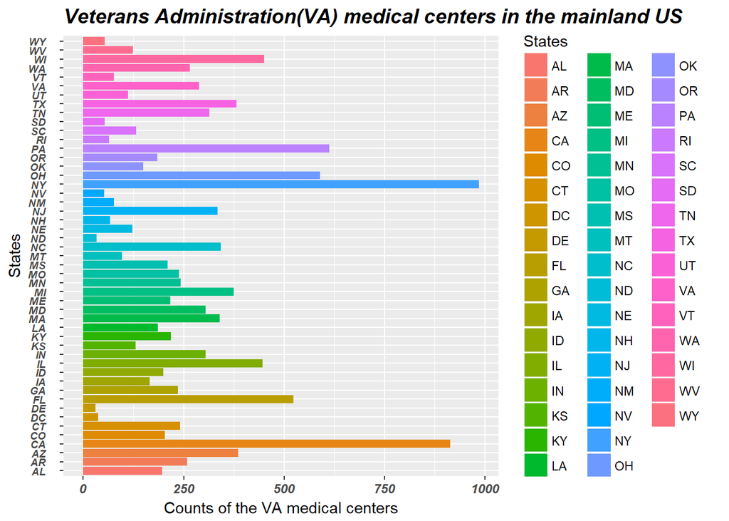

```r
library(ggplot2)
mytheme <- theme(plot.title = element_text(face = "bold.italic",size= 14, color = "black"), axis.text.x = element_text(size = 9, face ="bold.italic"), axis.text.y = element_text(face = "bold.italic", size = 7))
ggplot(data = Final_States_Freq, aes(x = Final_States_Freq$States, y = Final_States_Freq$Freq, fill=States), horis=TRUE)+geom_bar(stat = "identity")+labs(title = "Veterans Administration(VA) medical centers in the mainland US", x="States",y="Counts of the VA medical centers")+mytheme+coord_flip()
```

### 2. Cleaning and Bringing in New Features (60%)

1. This graph (1D) might be somewhat misleading, as bigger states may have more hospitals, but could be more sparsely located. Read statesize.csv into your R environment. This contains essentially a vector of square miles for each state. In trying to merge it with your data.frame() from 1C, you find that they don’t match. Use paste() on your LST column in 1C to see what the matter is, and write what you observe in a comment.
2. Correct the problem with the LST column using any method in R that is programmatic and easily understandable. Once you have made these state abbreviations identical to statesize.csv’s Abbrev column, merge the data.frame() from 1C and statesize.csv in order to add size information.

```r
statesize <- read.csv("~/R_files/statesize.csv")
#Lets compare variable's class in both data sets
str(Final_States_Freq)
```

```
## 'data.frame':    49 obs. of  2 variables:
##  $ States: Factor w/ 55 levels "AK    ","AL    ",..: 2 3 5 6 7 8 9 10 11 12 ...
##  $ Freq  : int  197 259 386 913 203 241 38 31 523 236 ...
```

```r
str(statesize)
```

```
## 'data.frame':    50 obs. of  4 variables:
##  $ StateName: Factor w/ 50 levels "Alabama","Alaska",..: 1 2 3 4 5 6 7 8 9 10 ...
##  $ SqMiles  : int  50750 570374 113642 52075 155973 103730 4845 1955 53997 57919 ...
##  $ Abbrev   : Factor w/ 50 levels "AK","AL","AR",..: 2 1 4 3 5 6 7 8 9 10 ...
##  $ Region   : Factor w/ 4 levels "Midwest","Northeast",..: 3 4 4 3 4 4 2 3 3 3 ...
```

```r
#Lets rename "Abbrev" for "States" in the "statesize" data set
names(statesize) <- c("StateName","SqMiles","States","Region")
#Lets merge two data sets
MergedData <- merge(Final_States_Freq, statesize, by="States", all=TRUE)
head(MergedData,5)
```

```
##   States Freq StateName SqMiles Region
## 1 AL      197      <NA>      NA   <NA>
## 2 AR      259      <NA>      NA   <NA>
## 3 AZ      386      <NA>      NA   <NA>
## 4 CA      913      <NA>      NA   <NA>
## 5 CO      203      <NA>      NA   <NA>
```

```r
#Data sets do not match, lets find out why
paste(Final_States_Freq$States)
```

```
##  [1] "AL    " "AR    " "AZ    " "CA    " "CO    " "CT    " "DC    "
##  [8] "DE    " "FL    " "GA    " "IA    " "ID    " "IL    " "IN    "
## [15] "KS    " "KY    " "LA    " "MA    " "MD    " "ME    " "MI    "
## [22] "MN    " "MO    " "MS    " "MT    " "NC    " "ND    " "NE    "
## [29] "NH    " "NJ    " "NM    " "NV    " "NY    " "OH    " "OK    "
## [36] "OR    " "PA    " "RI    " "SC    " "SD    " "TN    " "TX    "
## [43] "UT    " "VA    " "VT    " "WA    " "WI    " "WV    " "WY    "
```

```r
paste(statesize$States)
```

```
##  [1] "AL" "AK" "AZ" "AR" "CA" "CO" "CT" "DE" "FL" "GA" "HI" "ID" "IL" "IN"
## [15] "IA" "KS" "KY" "LA" "ME" "MD" "MA" "MI" "MN" "MS" "MO" "MT" "NE" "NV"
## [29] "NH" "NJ" "NM" "NY" "NC" "ND" "OH" "OK" "OR" "PA" "RI" "SC" "SD" "TN"
## [43] "TX" "UT" "VT" "VA" "WA" "WV" "WI" "WY"
```

```r
#We have extra spaces in the names of States in the Final_States_Freq data set, lets get rid of them
for (i in 1:4) {
    Final_States_Freq$States <- gsub('.{ }$', '',Final_States_Freq$States)
}
paste(Final_States_Freq$States)
```

```
##  [1] "AL" "AR" "AZ" "CA" "CO" "CT" "DC" "DE" "FL" "GA" "IA" "ID" "IL" "IN"
## [15] "KS" "KY" "LA" "MA" "MD" "ME" "MI" "MN" "MO" "MS" "MT" "NC" "ND" "NE"
## [29] "NH" "NJ" "NM" "NV" "NY" "OH" "OK" "OR" "PA" "RI" "SC" "SD" "TN" "TX"
## [43] "UT" "VA" "VT" "WA" "WI" "WV" "WY"
```

```r
#Now we can merge data sets
MergedData <- merge(Final_States_Freq, statesize, by="States", all=TRUE)
#Lets get rid of NAs
Final_MergedData1 <- subset(x=MergedData, !is.na(MergedData$Freq))
Final_MergedData <- subset(x=Final_MergedData1, !is.na(Final_MergedData1$SqMiles))
head(Final_MergedData,10)
```

```
##    States Freq   StateName SqMiles    Region
## 2      AL  197     Alabama   50750     South
## 3      AR  259    Arkansas   52075     South
## 4      AZ  386     Arizona  113642      West
## 5      CA  913  California  155973      West
## 6      CO  203    Colorado  103730      West
## 7      CT  241 Connecticut    4845 Northeast
## 9      DE   31    Delaware    1955     South
## 10     FL  523     Florida   53997     South
## 11     GA  236     Georgia   57919     South
## 13     IA  166        Iowa   55875   Midwest
```

3. Calculate a new variable in your combined data.frame() which indicates the VA hospitals per thousand square miles.

```r
Hospitals_per_ThousandSQmiles <- c((Final_MergedData$Freq*1000)/Final_MergedData$SqMiles)
Final_MergedData$Hospitals_per_ThousandSQmiles <- paste(Hospitals_per_ThousandSQmiles)
head(Final_MergedData,5)
```

```
##   States Freq  StateName SqMiles Region Hospitals_per_ThousandSQmiles
## 2     AL  197    Alabama   50750  South              3.88177339901478
## 3     AR  259   Arkansas   52075  South              4.97359577532405
## 4     AZ  386    Arizona  113642   West              3.39663152707626
## 5     CA  913 California  155973   West              5.85357722169863
## 6     CO  203   Colorado  103730   West              1.95700375976092
```

4. Create another ggplot which considers the VAs per square thousand miles, rather than just frequency.

• Make sure the State axis is readable, like before. Change the title and axes as appropriate.

• Modify the ggplot syntax to make your bars in descending order (there are StackOverflow topics for this, and I have demonstrated how in Live Coding in prior classes).

• Color-code the bars based on Region (see the merged data.frame)—however, change the color scheme from the default. Any set of colors is fine, so long as it is readable.

• Keep the legend—you should have four regions and therefore four colors.

```r
Final_MergedData$Hospitals_per_ThousandSQmiles <- as.numeric(Final_MergedData$Hospitals_per_ThousandSQmiles)
str(Final_MergedData)
```

```
## 'data.frame':    48 obs. of  6 variables:
##  $ States                       : chr  "AL" "AR" "AZ" "CA" ...
##  $ Freq                         : int  197 259 386 913 203 241 31 523 236 166 ...
##  $ StateName                    : Factor w/ 50 levels "Alabama","Alaska",..: 1 4 3 5 6 7 8 9 10 15 ...
##  $ SqMiles                      : int  50750 52075 113642 155973 103730 4845 1955 53997 57919 55875 ...
##  $ Region                       : Factor w/ 4 levels "Midwest","Northeast",..: 3 3 4 4 4 2 3 3 3 1 ...
##  $ Hospitals_per_ThousandSQmiles: num  3.88 4.97 3.4 5.85 1.96 ...
```

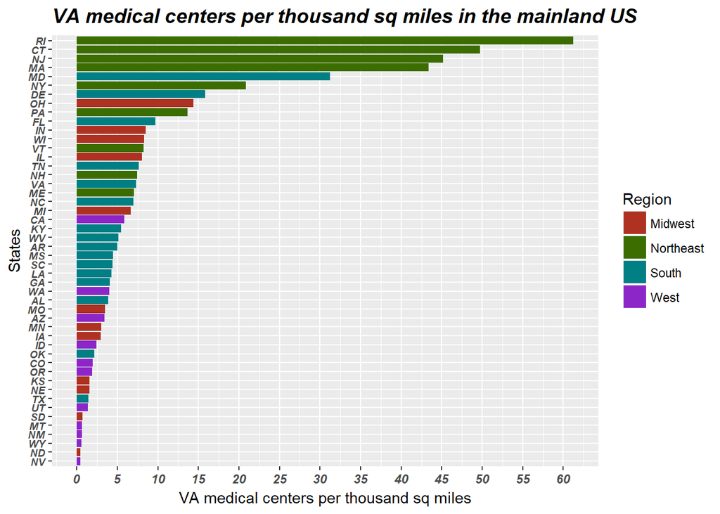

```r
mytheme <- theme(plot.title = element_text(face = "bold.italic",size= 14, color = "black"), axis.text.x = element_text(face ="bold.italic"), axis.text.y = element_text(face = "bold.italic", size = 7))
Final_MergedData$States <- factor(Final_MergedData$States, levels = Final_MergedData$States[order(Final_MergedData$Hospitals_per_ThousandSQmiles)])
ggplot(data = Final_MergedData, aes(x = Final_MergedData$States, y = Final_MergedData$Hospitals_per_ThousandSQmiles, fill=Region), horis=TRUE)+geom_bar(stat = "identity")+labs(title = "VA medical centers per thousand sq miles in the mainland US", x="States",y="VA medical centers per thousand sq miles")+mytheme+coord_flip()+scale_fill_hue(l=40) + scale_y_continuous(breaks=seq(0, 65, 5))
```

5. What patterns do you see? By this metric, is there any region that seems relatively high for VA medical centers per thousand square miles? How about low? Given these data, what advice might you give your boss before you start modeling (and why)?

Based on above plot we can say that Northeast Region has the highest value of the VA medical centers per thousand square miles, and West Region has the lowest value. At this point my advice is to build new hospitals in the West Region.